# LBM_analysis

# 2 Exploring Clustering associations

## 2.1 ASV-Host association - Model parameters

values = the probabilities of connections or edges between nodes in different blocks as found by the model.  
represent the probabilities of an edge existing between a pair of blocks.

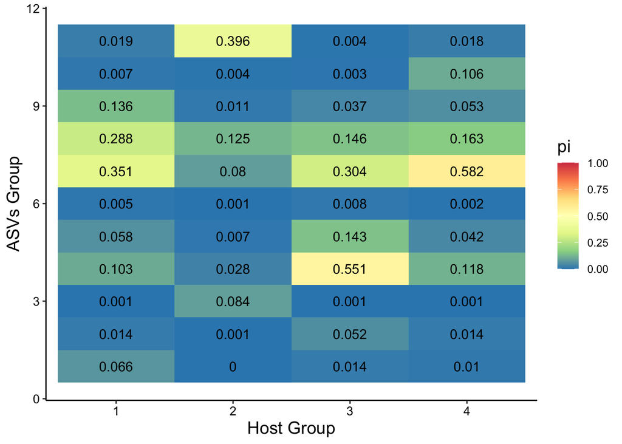

# 3 Exploring ASVs groups

## 3.1 Relative abundance

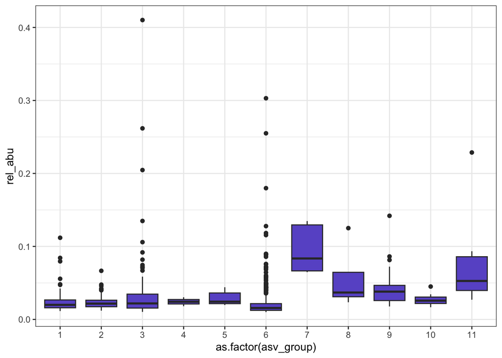

## 3.2 Occurrence

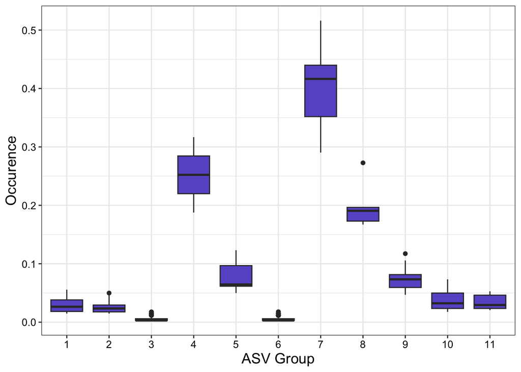

## 3.3 ASVs Season

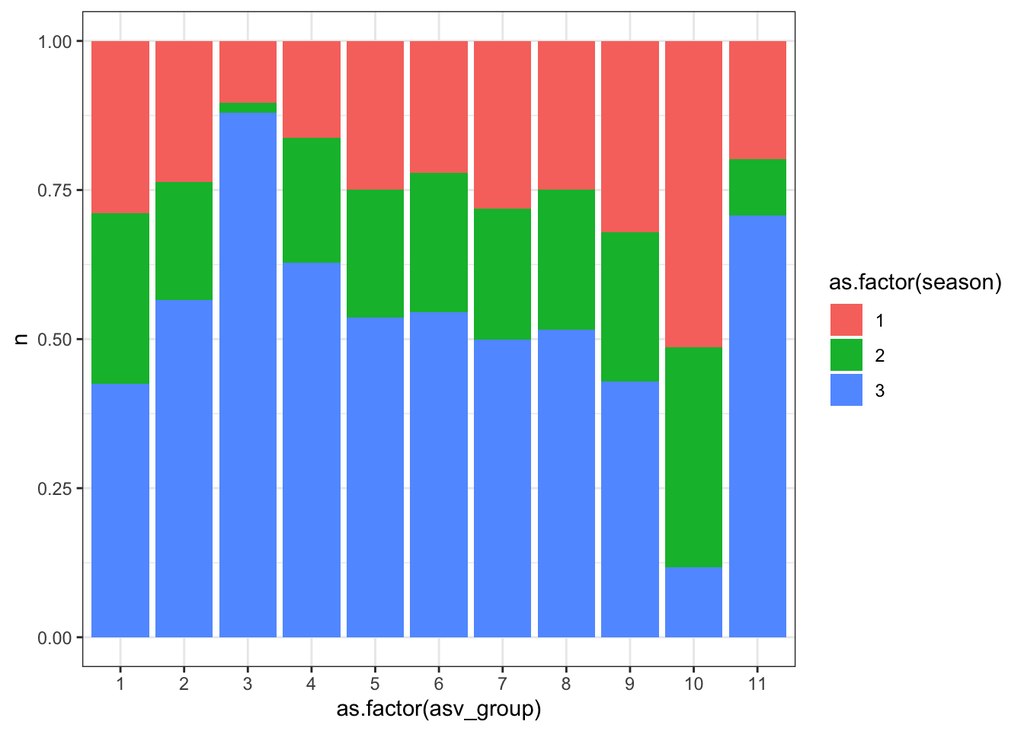

Shuffling season and calculating Normalized Mutual Information (NMI)

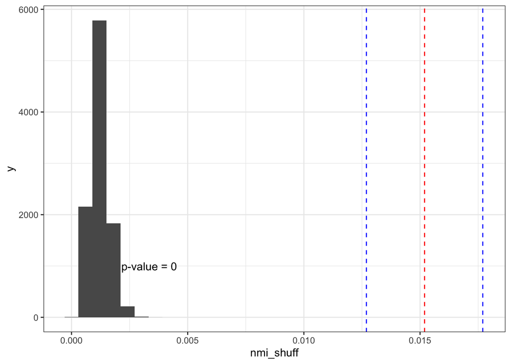

Density

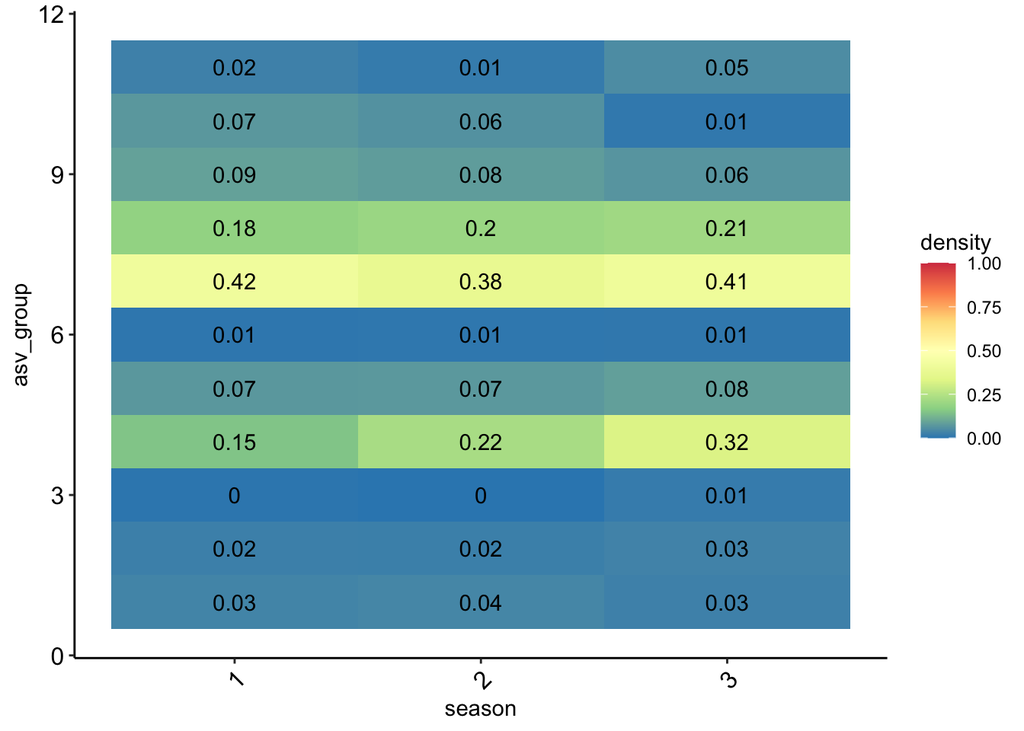

## 3.4 Phylogenetic distance

I calculate the *median* phylogenetic distance within each group (Intra) and between groups (Inter).  
Then I calculate log(intra/inter) between all groups.  
Negative values = group x is closer to itself than to other groups.

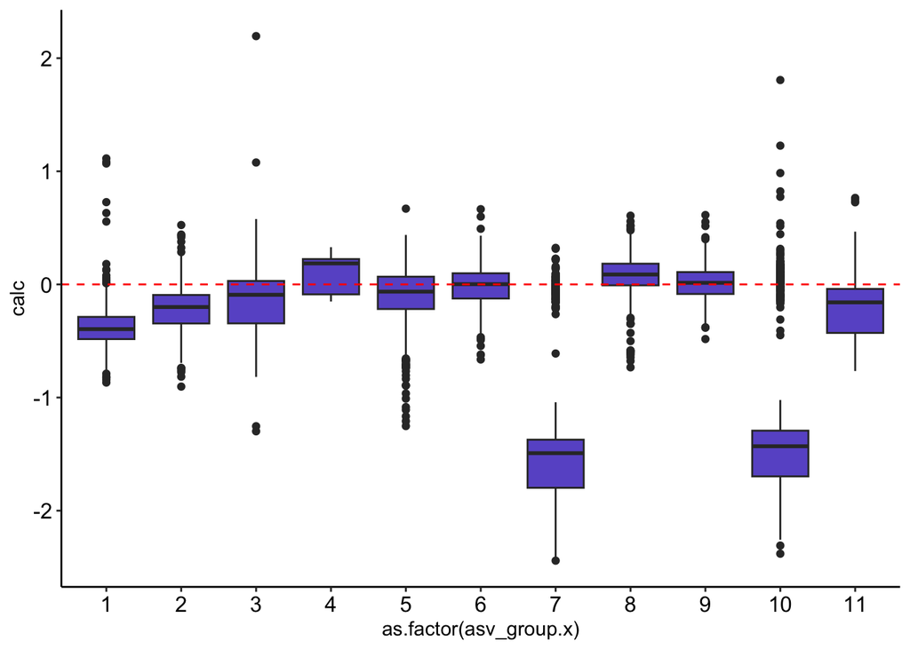

## 3.5 ASVs Taxonomy

Proportion of taxa (minimum 2 ASVs per taxa)

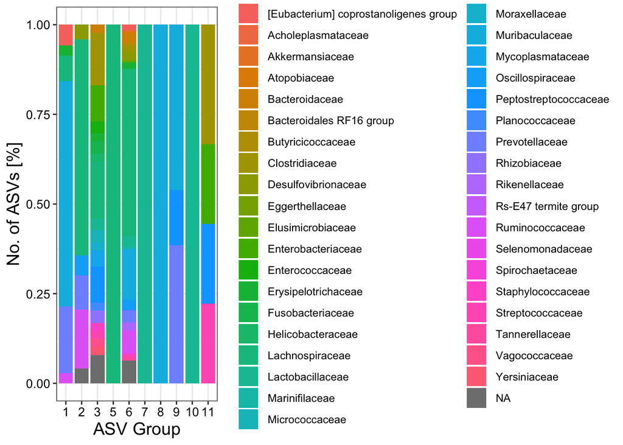

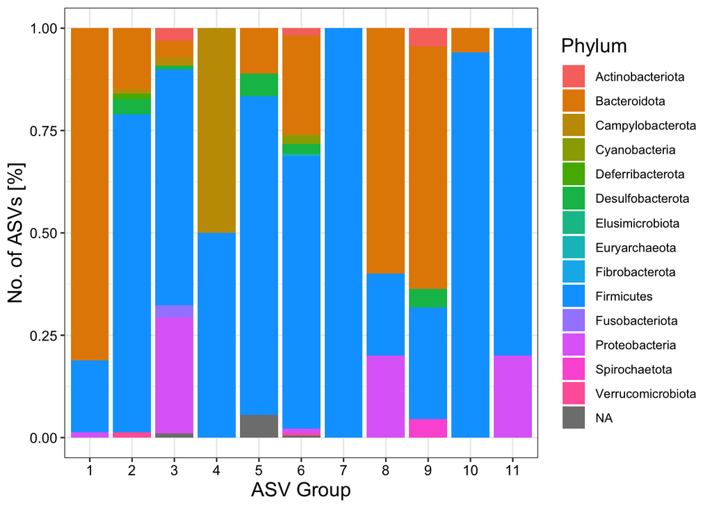

# 4 ASVs Land-Use

## 4.1 Z-scores

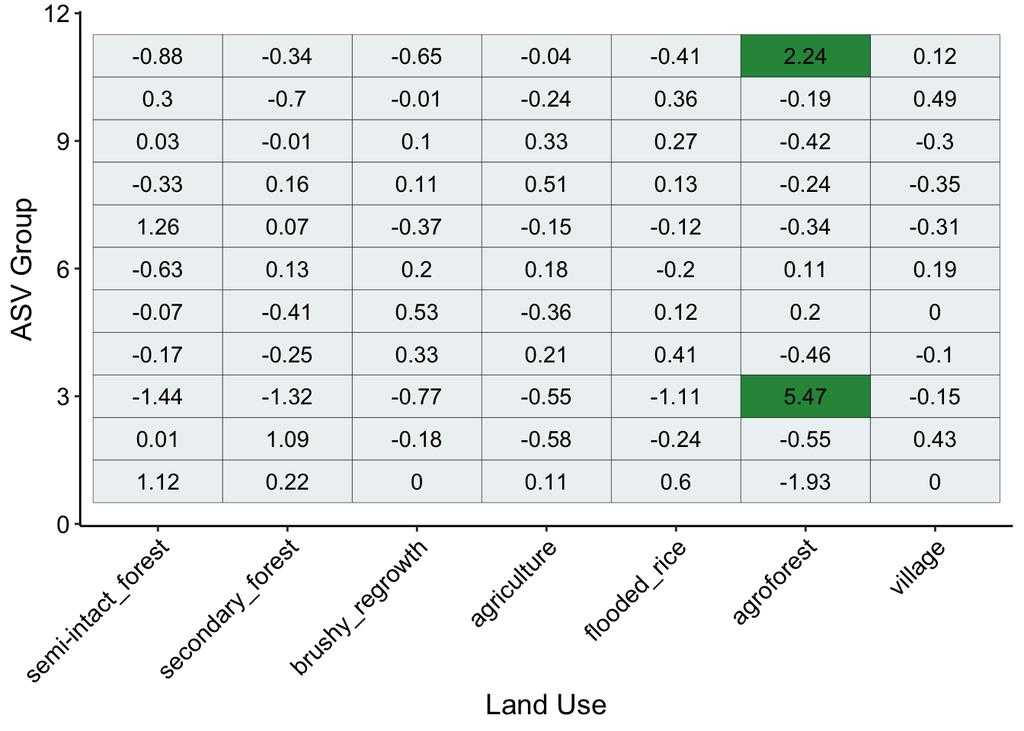

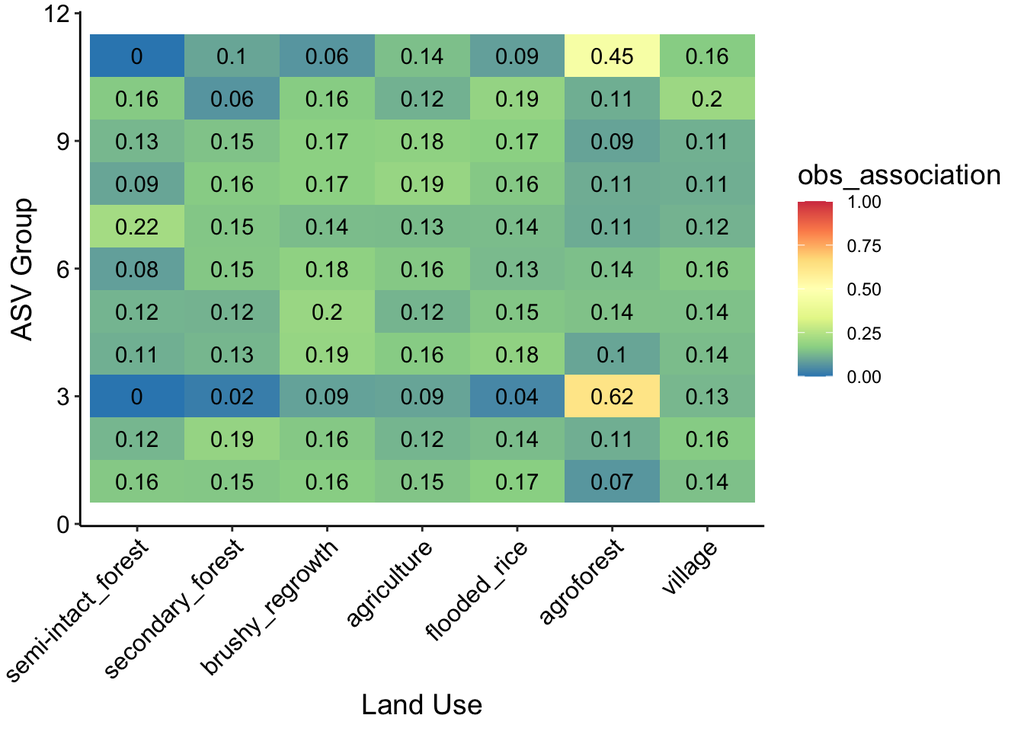

## 4.2 % of ASVs

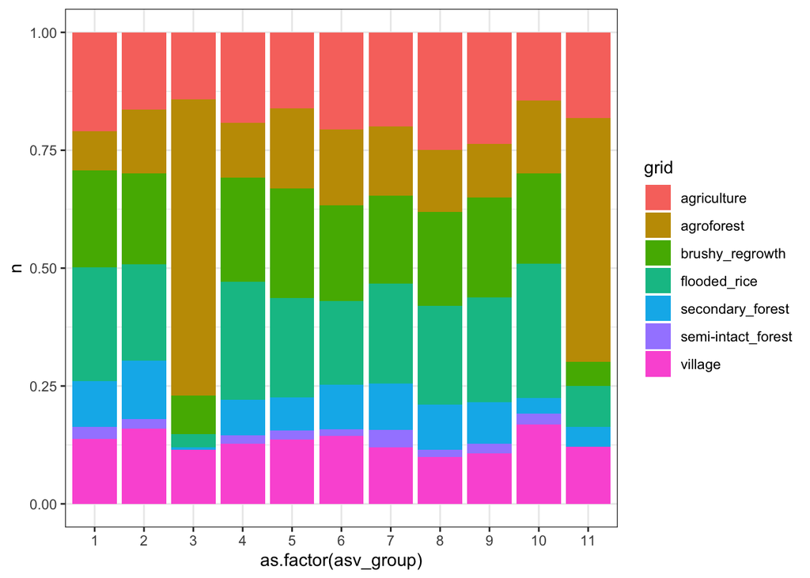

## 4.3 NMI

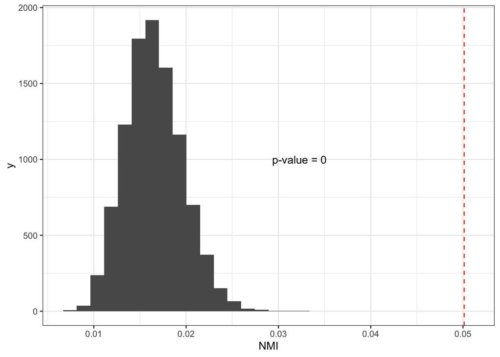

## 4.4 Beta-Diversity

asv_group similarity [Jaccard] across grids  
value = average similarity of the grid to all other grids

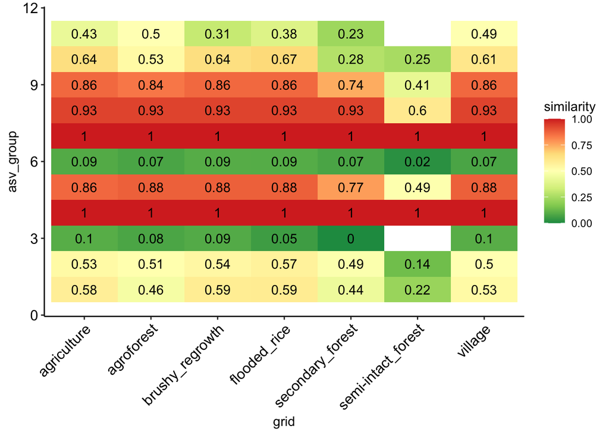

# 5 Exploring Host groups

## 5.1 ASVs Richness

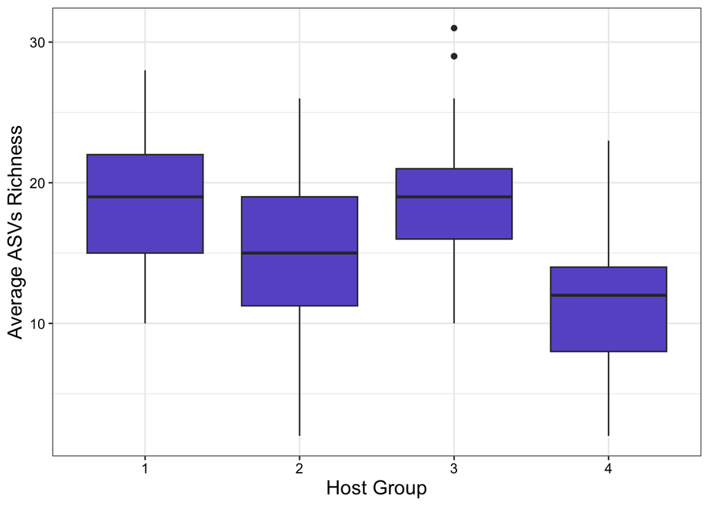

## 5.2 ASVs Group Richness

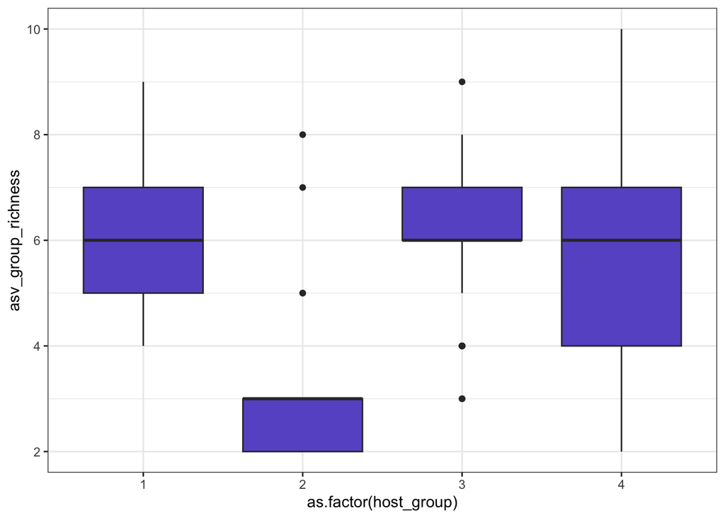

## 5.3 Host Mass

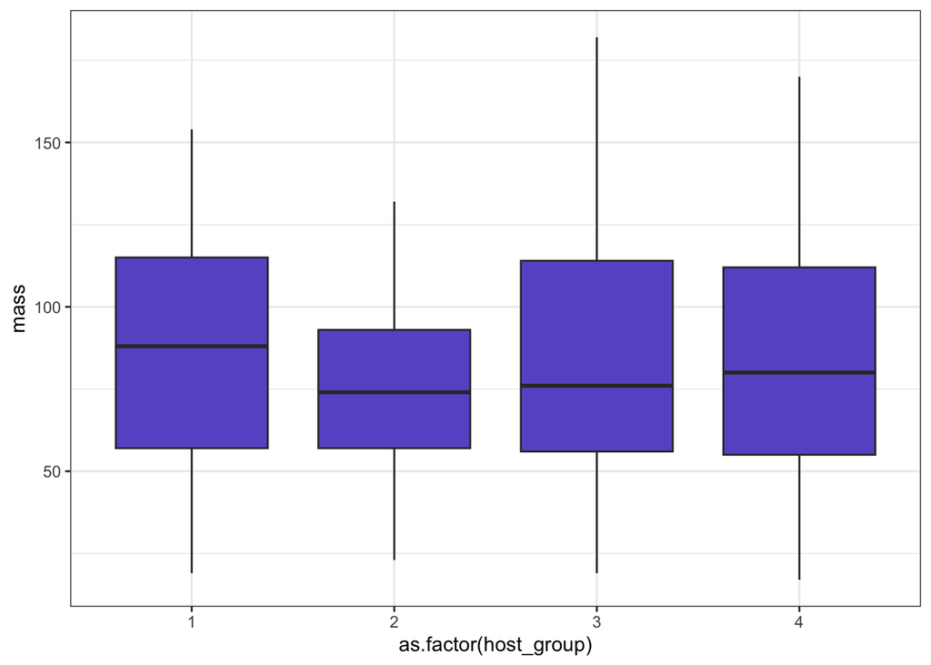

## 5.4 Host Sex Ratio

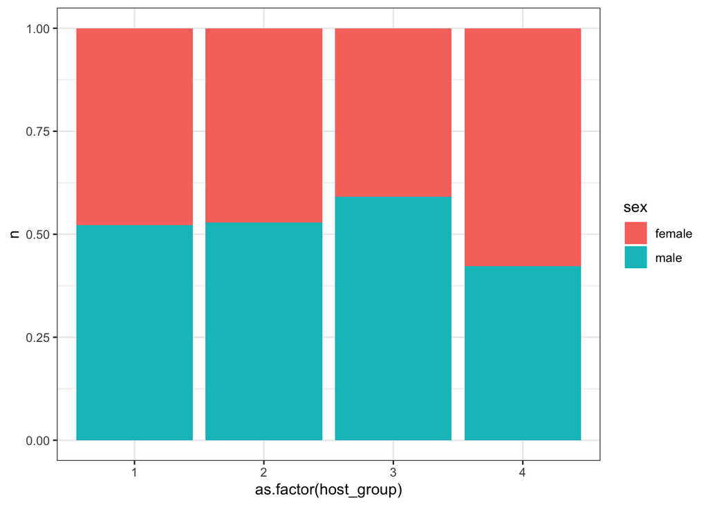

## 5.5 Host Land-Use

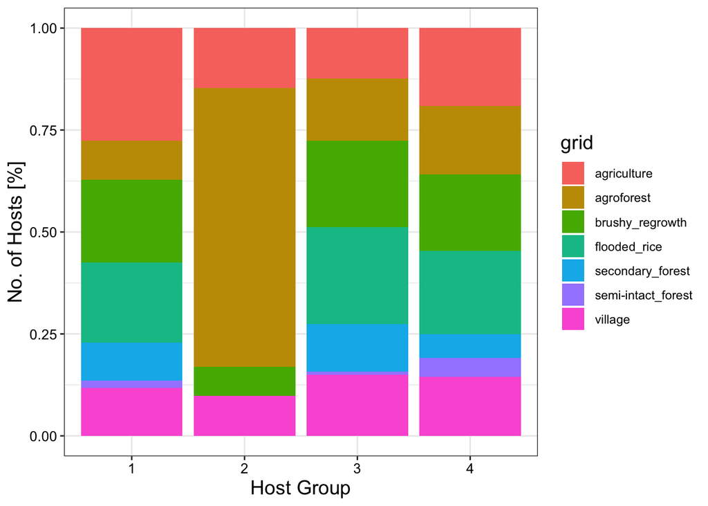

Shuffling land-use and calculating Normalized Mutual Information (NMI)

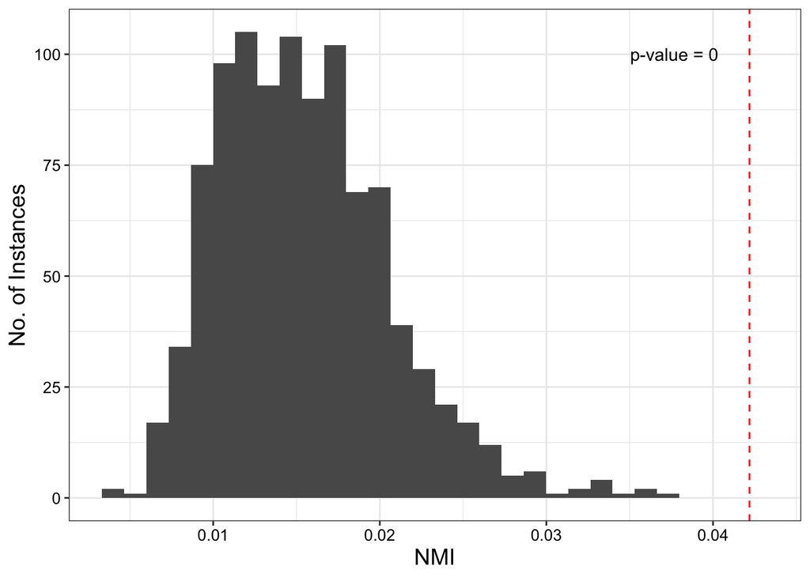

## 5.6 Host Season

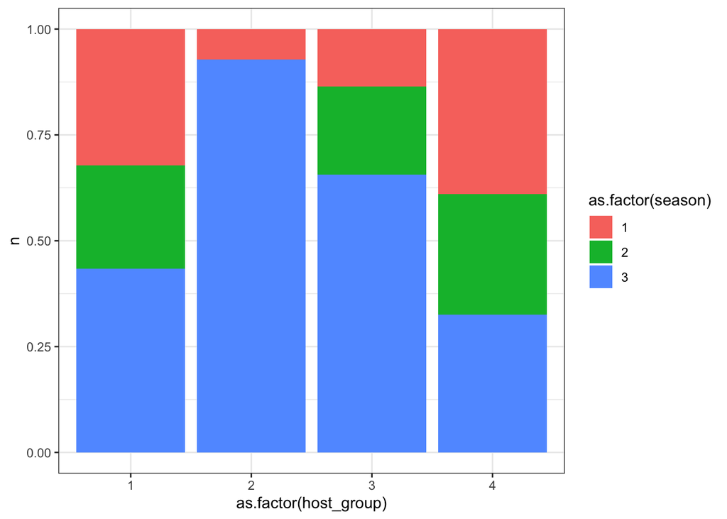